# Title: Cooling benefits and forest structure similar across parks with varied land use histories

Authors: Isabella C. Richmond<sup>1</sup>*, Michael A. Paulauskas<sup>1</sup>, Erica Padvaiskas<sup>1</sup>, Laura Carolina Gonzalez Sinisterra<sup>2</sup>, Kayleigh Hutt-Taylor<sup>1</sup>, Alec L. Robitaille<sup>3</sup>, Carly D. Ziter<sup>1</sup>

1 Department of Biology, Concordia University, Montreal Canada, H4B 1R6  
2 Department of Biology, Universidad del Valle, Cali Columbia, 760042 3 Department of Biology, Memorial University of Newfoundland, St John’s Canada, A1C 5S7

* isabella.richmond@mail.concordia.ca, 438-439-8064

## Prior Predictive Checks

Prior predictive checks are used to ensure that the values selected for priors for our models allow a biologically reasonable range of values. For models with fixed effects fit to the model (models 1 and 5), we simulate predictive draws for prior only models and visualize the slope/intercept of the values. We then do a “posterior predictive check” but with the prior only model, to see if the data is captured in the priors. For models with only random effects, we only use the posterior predictive check.

## Model 1: Total Effect of Past Land-Use on Temperature

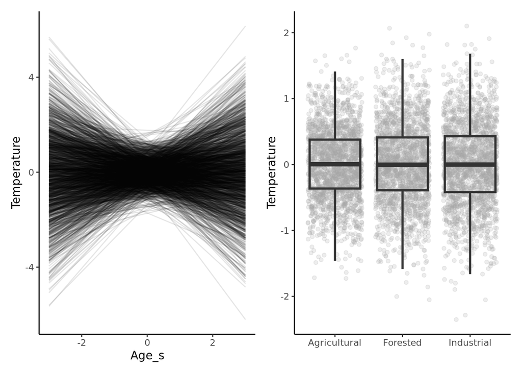

## Model 2a: Direct Effect of Past Land-Use on Large Tree (>= 5 cm DBH) Basal Area

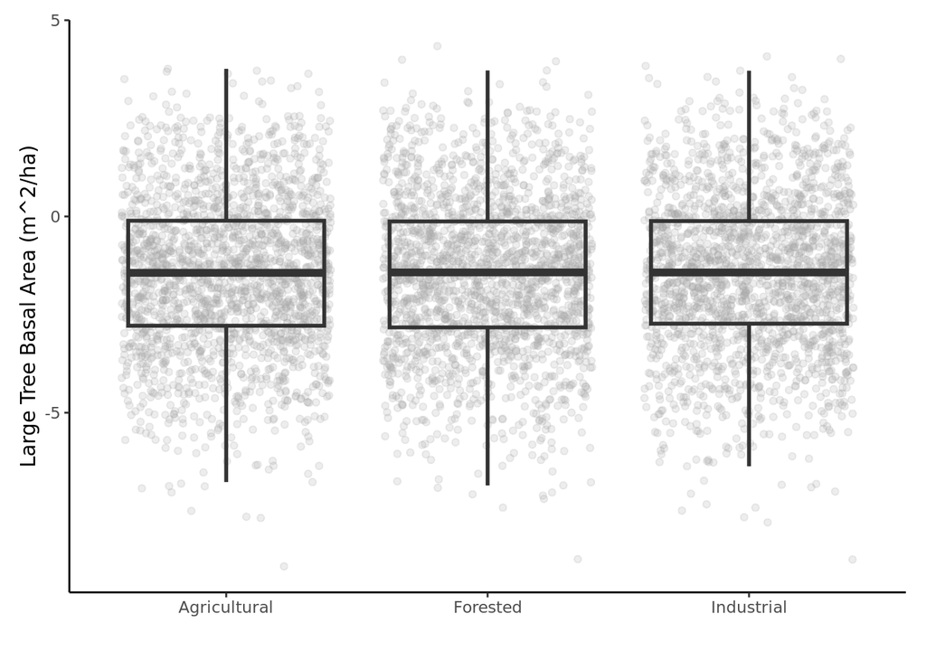

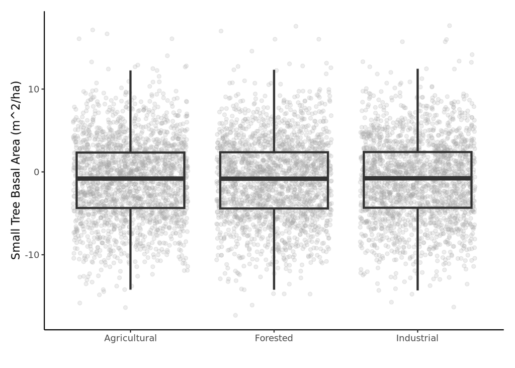

## Model 3a: Direct Effect of Past Land-Use on Large Tree (>= 5 cm DBH) Size

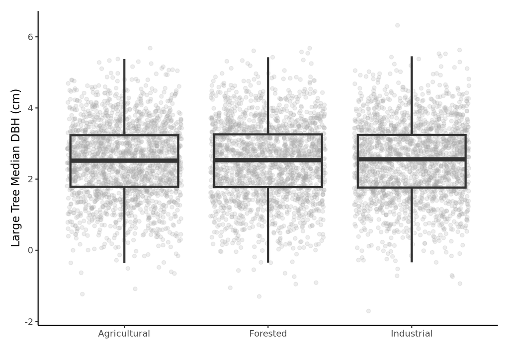

## Model 3b: Direct Effect of Past Land-Use on Small Tree (< 5 cm DBH) Size

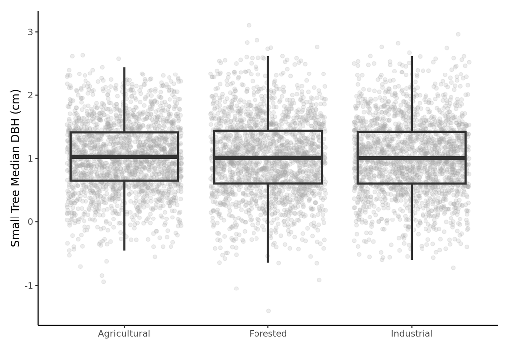

## Model 4: Direct Effect of Past Land-Use on Large Tree (>= 5 cm DBH) Species Richness

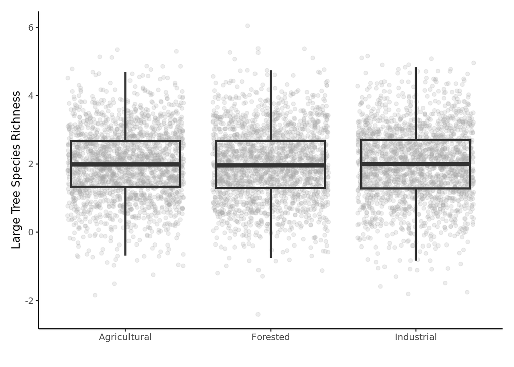

## Model 5: Direct Effect of Forest Composition on Temperature

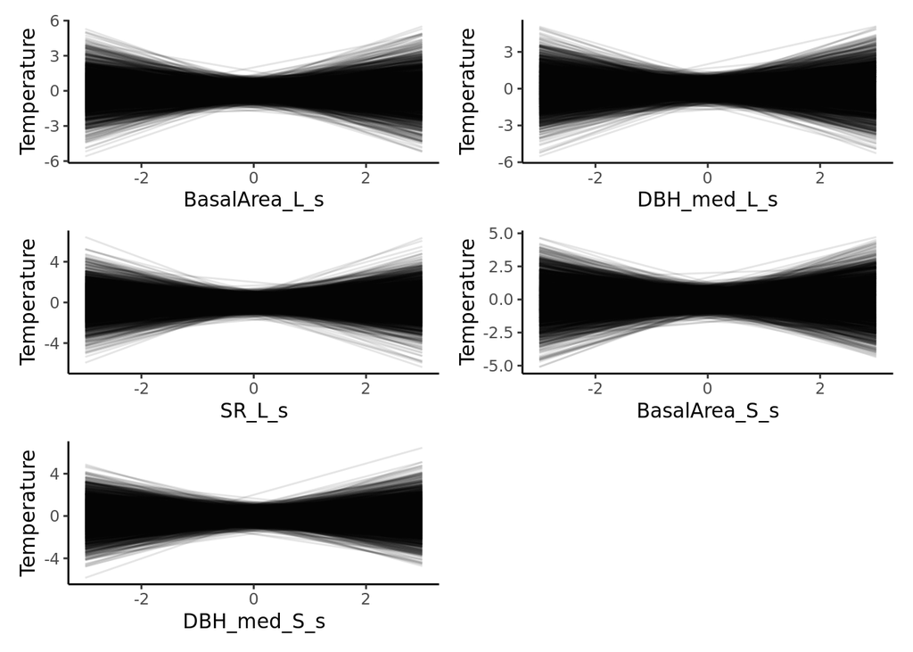